# Damiano Michieletto - Bayerische Staatsoper

[figure not shown]

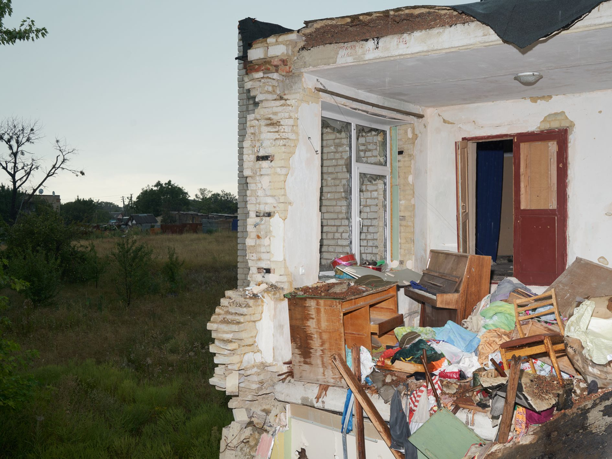

# MICH INTERESSIERT DER FOKUS AUF ALLES MILITÄRISCHE NICHT

Interview mit Regisseur Damiano Michieletto

<sub>Lesedauer: 8 min.</sub>  
Giuseppe Verdi und Antonio Ghislanzoni zoomen unvermittelt in einen bestehenden Konflikt, wir steigen mit der ersten Szene direkt in die militärische Handlung ein.  
Wie lesen Sie den militärischen Konflikt zweier Nationen in Aida*?*

Ich interpretiere ihn als Bürgerkrieg. Die Menschen sind auf Gewalt nicht vorbereitet. Der Tod entfaltet eine so verheerende Wirkung, weil er in den Alltag, in die Familien einbricht, Kinder nicht verschont. Den Stoff möchte ich nicht als militärische Geschichte, sondern als etwas vermitteln, das der Zivilbevölkerung widerfährt.  
Die Gesellschaft, wie ich sie in *Aida* zeige, trifft sich an einem symbolträchtigen Ort der Stadt, der durch den Konflikt in Schutt und Asche gelegt wurde. Zuvor hatte man sich dort zum Spielen getroffen, zum Vergnügen und zur Zerstreuung, seine Freizeit hier verbracht. Jetzt stehen dort Särge und es liegen Verletzte in dem Raum. Und es finden Zeremonien und Überlegungen darüber statt, wozu der Mensch letztlich existiert.

*Verdis Musik stellt zwei Welten gegeneinander: die intime Liebesgeschichte und die brachiale, monumentale Kriegshandlung, die die Ebene der politischen Macht miteinschließt.*

Verdi hat seiner Musik sicherlich einen bewusst triumphierenden Charakter verliehen, weil *Aida* ein Auftragswerk war. Denken wir an die Olympischen Spiele, dort werden sehr aufwändige Festakte veranstaltet.  
Müsste jemand ein Werk zur Einweihung eines Stadions komponieren, die erste Inspirationsquelle wäre wohl *Aida*.  
Aber das ist eine Frage der Perspektive auf das Werk.  
Mich interessiert der Krieg als Fokus auf alles Militärische nicht, mich interessieren die Folgen von Krieg und Gewalt für die Figuren, die Handelnden. Im Triumphmarsch wird der Sieg gefeiert, ja, aber auch der bringt Verluste und Niederlagen mit sich. Man ehrt hier die Tapferen, die die Insignien des Krieges tragen. Die Erfahrung des Krieges hat infolge unmenschlicher Handlungen sowohl Seelen traumatisiert als auch Körper verstümmelt.

*Die Liebesgeschichte zwischen Aida und Radamès ist verwoben mit der Dynamik dieses Krieges. Wie hängt beides für Euch zusammen?*

Ihre Geschichte ist eine kleine Geschichte in einem größeren Erzählrahmen. Eine Privatsache innerhalb einer öffentlichen Angelegenheit. Das Schicksal des Einzelnen wird also von einer größeren Macht bestimmt. Sind die beiden frei?  
Nein, sind sie nicht. Ihre Entscheidungen werden gesteuert, und, was bei Verdi ja keine Seltenheit ist: am Schluss dieser großen Geschichte der Massen erpressen die Eltern ihre eigenen Kinder.  
Ein Leitmotiv, das sich in seinen Werken öfter findet. Man denke hier nur an *Rigoletto, La Traviata* oder *Luisa Miller*. Auch Aida wird von ihrem Vater gezwungen, Radamès zu verraten.

*Welche Rolle spielen Ramfis und Amonasro?*

Ich habe Ramfis seine übliche religiöse Funktion genommen. Er ist hier insofern Gegenspieler von Radamès, weil er sich zum wahren politischen Drahtzieher entwickelt.  
Als Berater des Pharaos prägt er dessen Entscheidungen. Am Ende nimmt er Amneris zur Frau – was er auch von Anfang an vorhatte. Den Brautschleier, den Amneris bei ihrer Vermählung mit Radamès tragen wollte, wird sie zur Eheschließung mit einem Anderen tragen. Amonasro ist mit Blick auf den Pharao die Kehrseite der Medaille:  
Hier gibt es keine offenkundig Guten und Bösen. Die einen wie die anderen pochen auf ihre Machtansprüche und führen so ihr Volk ins Verderben.

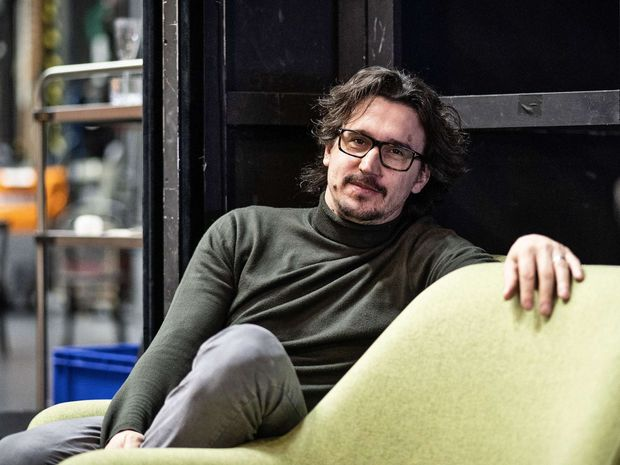

## DAMIANO MICHIELETTO

Der italienische Regisseur Damiano Michieletto studierte Opern- und Theaterregie an der Scuola d’Arte Drammatica Paolo Grassi in Mailand und moderne Literatur an der Università Ca’ Foscari in seiner Heimatstadt Venedig. Seine Inszenierung von Weinbergers *Schwanda, der Dudelsackpfeifer* beim Wexford Festival 2003 gewann einen Irish Times/ESB Theatre Award, gefolgt von Arbeiten für das Rossini Opera Festival in Pesaro, die Salzburger Festspiele, die Mailänder Scala. Er inszenierte an den führenden Häusern in Amsterdam, London, Wien, Paris, Berlin, Moskau, Venedig, Rom, am Bolschoi-Theater in Moskau oder an der Oper Frankfurt, an der Opéra de Lyon, beim Glyndebourne Festival, an der Staatsoper unter den Linden Berlin, Gran Teatre del Liceu Barcelona, dem Teatro La Fenice oder dem Teatro Real in Madrid. Neben seiner intensiven Tätigkeit als Opernregisseur arbeitet Michieletto auch als Theaterregisseur, speziell für das Teatro Stabile del Veneto und das Piccolo Teatro in Mailand. Neuproduktion der letzten Zeit waren u. a. C. W. Glucks *Orfeo ed Euridice* an der Komischen Oper Berlin, G. Battistellis *Le baruffe* am Teatro La Fenice, G. F. Händels *Giulio Cesare in Egitto* am Théâtre des Champs-Elysées, die italienischen Erstaufführungen von L. Bernsteins *Mass* in Rom sowie die Uraufführung von Raskatovs *Animal Farm* an De Nationale Opera in Amsterdam. Mit der Produktion von *Aida* stellt er erstmals eine Arbeit in München vor.

*In der ersten Szene der Oper stellt sich Radamès vor, den Kampf gegen die Gruppe von Menschen erfolgreich anzuführen, zu denen seine Geliebte Aida gehört – und kehrt dann mit den Worten zu ihr zurück: „Für dich kämpfte ich, für dich siegte ich!“ Diese Widersprüchlichkeit prägt auch die Musik der ersten Szene: Wenn Radamès einerseits vom Siegen, andererseits von seiner Liebe zu Aida fantasiert, kontrastiert Verdi scharfe Fanfarenklänge mit einem zarten, innerlichen Streichersatz. Verdi legt damit den Konflikt, der die Unmöglichkeit der Liebe zwischen Aida und Radamès im Kern ausmacht, doch von Anfang an in Radamès selbst. Spricht die Widersprüchlichkeit seines Charakters für eine geringe Reife eines jungen Mannes, ist er einfach nur naiv?*

Radamès hat weder die Mittel noch die nötige Reife, um erfolgreich in einen Krieg zu ziehen. Zu Beginn vernimmt man von ihm die Zeile „Se quel guerrier io fossi“ („Wenn ich jener Krieger wäre …“), aus der Zweifel, Unsicherheit zu lesen ist.  
Er begreift gar nicht, was Gewalt ist, erst nach seiner Rückkehr hat ihn die Erfahrung von Gewalt für immer geprägt. Radamès steht für Unsicherheit, Hochmut, für das Instinktive. Ihm fehlt die Rationalität und das zynisch-erbarmungslose Kalkül eines Ramfis.

*Aida ist eine Außenseiterin. Im Gegensatz zu Radamès weiß sie von Anfang an, dass ihre Lage und ihre Liebe aussichtslos sind. Verdi und Ghislanzoni zeigen sie als Frau, die ihre Situation genau reflektiert. Hat sie von Anfang an aufgegeben?*

Aida träumt von ihrer verlorenen Heimat – ein bei Verdi immer wieder vorkommendes Motiv. Diese „verlorene Heimat“ ist aber in Wirklichkeit ihre Familie. Sie ist eine Halbwaise, und der damit verbundene Schmerz ist immer in ihr. Und sie ist unglaublich einsam.  
Ihre Liebe ist nicht frei von Hoffnung, und genau für diese Emotion geht sie schließlich in den Tod. Das hat etwas ausgesprochen Romantisches, wie bei Shakespeares Julia.

*Am Ende ist es also Aida, die die Liebe der beiden ermöglicht, wenn auch nur mit der Perspektive des gemeinsamen Sterbens? Spiegelt sich in der Figur Aida Giuseppe Verdi, der 58-jährig angesichts der gesellschaftlichen Realität resigniert ist?*

Ob Verdi sich hier widerspiegelt, kann ich nicht sagen.  
Ich glaube aber, dass er und Ghislanzoni hier ein leidvolles Finale schaffen wollten. In meinen Augen fällt dieses Finale nicht mit dem Tod der beiden zusammen, sondern mit ihrer letzten Vereinigung.  
Es ist fast wie eine Trauung. Im Finale wird Resignation also zu einer Vision des Einsseins, der Hoffnung.

*Sie beschäftigen sich unter anderem mit René Girards historischer Theorie des „Sündenbocks“. Was hat es damit auf sich?*

Nach Girard werden zwischenmenschliche Konflikte nicht durch unsere Differenzen, sondern vielmehr durch unsere Gemeinsamkeiten hervorgerufen.  
Beispiel: Amonasro und der Pharao. Sie sind einander ähnlich. Zum Sündenbock wird hier, wer sich dieser Logik entzieht und in die Opferrolle gerät. Romeo und Julia entziehen sich der Logik, die aus den Montagues und den Capulets verfeindete Familien macht und sind dadurch dem Tod geweiht. Es gibt keinen Platz für sie. Aida und Radamès stehen außerhalb der Rationalität des Krieges und haben deshalb keine Zukunft.

*Akzeptieren sie ihre Rolle als Sündenbock, indem sie sich am Ende freiwillig ‚opfern‘?*

Im vierten Akt wandelt sich das Leid zu einer Art Schicksalsgemeinschaft der Unsterblichkeit. Um Amneris oder Ramfis geht es nicht mehr, ebenso wenig um den Pharao. Wir sprechen hier (auch in diesem Interview!) von Aida und Radamès. Also vonjenen, die alles verloren haben, dabei aber Unsterblichkeit erlangen. Dass sie zu Sündenböcken werden, ist also die Folge einer bewussten Entscheidung: Radamès hätte ja die Kerkerhaft vermeiden, und Aida hätte ihn verlassen können.  
Es handelt sich also nicht um eine Verurteilung, sondern eine bewusste Entscheidung. Und in der lese ich, ästhetisch gesprochen, ein Moment der Einheit, es führt die beiden zurück zu ihrem Streben nach Glück. Das Finale wird zu ihrem Triumph.

*Was geschieht nach dem Tod von Radamès und Aida?*

Die Gesellschaft gerät unter die Führung von Ramfis, der nach der Ermordung von Amonasro die Tochter des Pharaos heiratet und so bekommt, was er schon immer wollte.  
Die Gesellschaft beerdigt ihre Toten, die Kamera entfernt sich langsam vom Ort des Grauens.

*Die Fragen stellte [Katharina Ortmann](https://www.staatsoper.de/biographien/ortmann-katharina)*

*Das Motiv stammt aus der Serie War Rooms des Fotografen Christopher Nunn. In seiner Dokumentation fotografierte Nunn durch Konflikt beschädigt und veränderte Schulen, Büros, Kulturgebäude, Wohnblocks und Privathäuser in der Ukraine.*

# AIDa

Oper in vier Akten (1871)

[ZUR PRODUKTION](https://www.staatsoper.de/stuecke/aida)

[interactive chart not shown]